# Assignment 3

Art Hussnain

2022-09-02

#### Marsupial mtDNA tree construction

1. First, the working directory needs to be organised

```bash
cd ~/Assignments/Assignment_3
mkdir mb_outputs
mkdir sequences
cd sequences
mkdir nex
mkdir mafft
mkdir gb
```

2. Now, we download the data to be used

```bash
wget https://university-of-adelaide-bx-masters.github.io/BIOTECH-7005-BIOINF-3000/Practicals/evolutionary_prac/fetch
chmod +x fetch
./fetch -email artemiyhussnain@gmail.com -query "mitochondrion[All Fields] AND \"Metatheria\"[Organism] AND \"complete genome\"[All fields] AND \"RefSeq\"[All fields]" -out metatheria_mtDNA.fa
```

```bash
head ~/Assignments/Assignment_3/metatheria_mtDNA.fa
```

```
## >NC_061372.1 Phascolosorex doriae mitochondrion, complete genome
## GTTTGTGTAGCTTAACATAAAGCAAAGCACTGAAAATGCTTAGATGGATTTTAATCAACCCCGCAGGCAC
## AAAGGTTTGGTCCTAGCCTTACTGTTAATTTTTATTAGACCTACACATGCAAGTTTCCGCAACCCTGTGA
## GTATGCCCTTTTAACTTTTACACGAGTCTAAAGGAGCTGGTATCAGGCACACTTATACAAGCAGCCCATG
## ACACCTTGTTTAACCACACCCCCACGGGTTACAGCAGTGACTAACATTGAGCCATAAACGAAAGTTTGAC
## TAAATCATAATAAATAAGGGTTGGTCAATCTCGTGCCAGCCACCGCGGTCATACGATTAACCCAAATTAA
## CAGAAGAACGGCGTAAAGGGTGTTTAAGCACGTAACCCACCAAATAAAGTTAAAGACCAACTGCGCTGTA
## ATACGCCCTAGTTGACATTAAAATACACAACCAACGTGACTTTACTAATGCTGAAGACACTAAAGCTAAG
## AAACAAACTGGGATTAGAGACCCCACTATGCTTAGCCGTAAACCTAGGTAATTAAATAACAAAATCACTC
## GCCAGAGAACTACAAGCTACTGCTTAAAACTCAAAGGACTTGGCGGTACCCTAGACCCTCCTAGAGGAGC
```

3. A multiple alignment is produced using MAFFT

```bash
mafft --help
mafft metatheria_mtDNA.fa > sequences/mafft/metatheria_mtDNA-mafft.fa
```

```bash
head ~/Assignments/Assignment_3/sequences/mafft/metatheria_mtDNA-mafft.fa
```

```
## >NC_061372.1 Phascolosorex doriae mitochondrion, complete genome
## ------------------------------------------------------------
## ------------------------------------------------------------
## ------------------------------------------------------------
## ------------------------------------------------------------
## ------------------------------------------------------------
## ------------------------------------------------------------
## ------------------------------------------------------------
## ------------------------------------------------------------
## ------------------------------------------------------------
```

4. The alignment is modified to be usable by Gblocks, a program that removes gaps from the multiple alignment, and fed into it

```bash
sed -e 's/^>[^ ]\+ \([^ ]\+\) \([^ ]\+\).*$/>\1_\2/g' ~/Assignments/Assignment_3/sequences/mafft/metatheria_mtDNA-mafft.fa > ~/Assignments/Assignment_3/sequences/gb/metatheria_mtDNA-named.fa
mkdir -p screenshots/gb
```

- Gblocks can only be run interactively, so screenshots of terminal output are provided

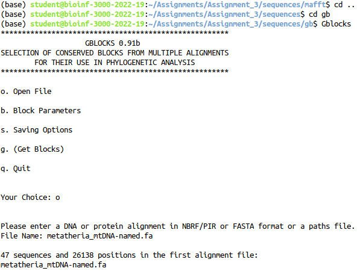

Gblocks 1

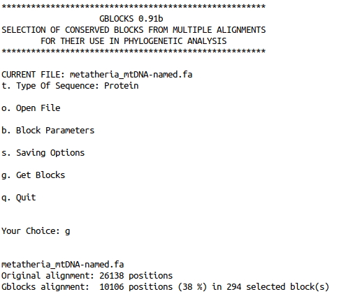

Gblocks 2

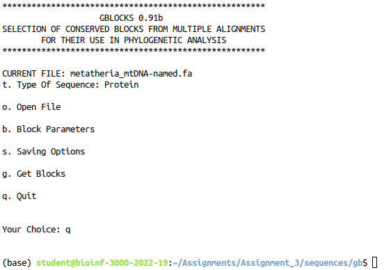

Gblocks 3

**Q1. What does sed do above?**

- `sed -e` looks for (`'s/`) ‘>’ at the start of a line, followed by anything other than a space (`^>[^ ]`), matches two space-separated instances of anything but a space following that (rest of expression until `/`), and returns the first and second match separated by ’_’ and preceded by ‘>’ (`>\1_\2`), applying the options globally (`/g`) ***
5. The NEXUS format can be used to visualise multiple alignments produced by MAFFT before proceeding to tree-building using Mr Bayes; Gblocks produces an HTML file with its alignment for visualisation, found at metatheria_mtDNA-named.fa-gb.htm

```bash
cd sequences/gb
seqmagick convert --output-format nexus --alphabet dna metatheria_mtDNA-named.fa metatheria_mtDNA-named.nex
```

```bash
head ~/Assignments/Assignment_3/sequences/gb/metatheria_mtDNA-named.nex
head ~/Assignments/Assignment_3/sequences/gb/metatheria_mtDNA-named.fa-gb
```

```
## #NEXUS
## begin data;
##  dimensions ntax=47 nchar=26138;
##  format datatype=dna missing=? gap=- interleave;
## matrix
## Phascolosorex_doriae      ----------------------------------------------------------------------
## Dasycercus_cristicauda    ----------------------------------------------------------------------
## Lutreolina_crassicaudata  ----------------------------------------------------------------------
## Didelphis_pernigra        ----------------------------------------------------------------------
## Didelphis_marsupialis     ----------------------------------------------------------------------
## >Phascolosorex_doriae
## cgacctcgat gttggatcag gacatccaaa tggtgcagcc gctattaaag gttcgtttgt
## tcaacgatta aagtcctacg tgatctgagt tcatccaggt cggtttctat ctgtactccc
## agtacgaaag gacaagagaa atagggccaa catacaagcc ctagaaatct aaatattcta
## attgcataaa gtttaagcct ttactcccag aggttcaaac cctcttctta atataatcaa
## ccttctactt tatattatcc caattctcct agcctcttat tgaacgcaaa gtattcatac
## aactccgaaa aggcccaaac attgtaggtc cttatggtct cctacagcca ttcgctgacg
## cagtaaaatt attcacaaaa gaacctctcc acccactaac ttcttcttta ttatagcccc
## catccttgat accatacacc ctattagact taaaccttgg actcatcttc atcctatcat
## tatctggctt atcagtttat tcaatcctat gatcaggatg agcctactca aaatattaat
```

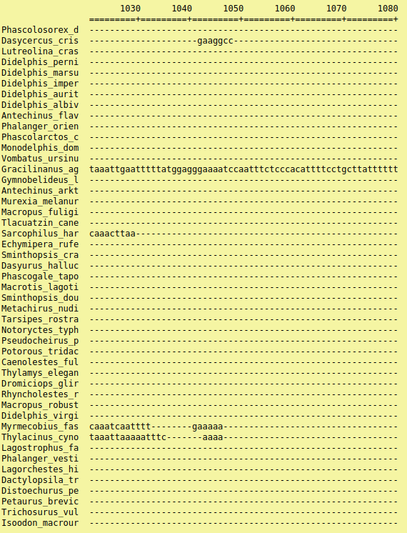

Gblocks HTML output

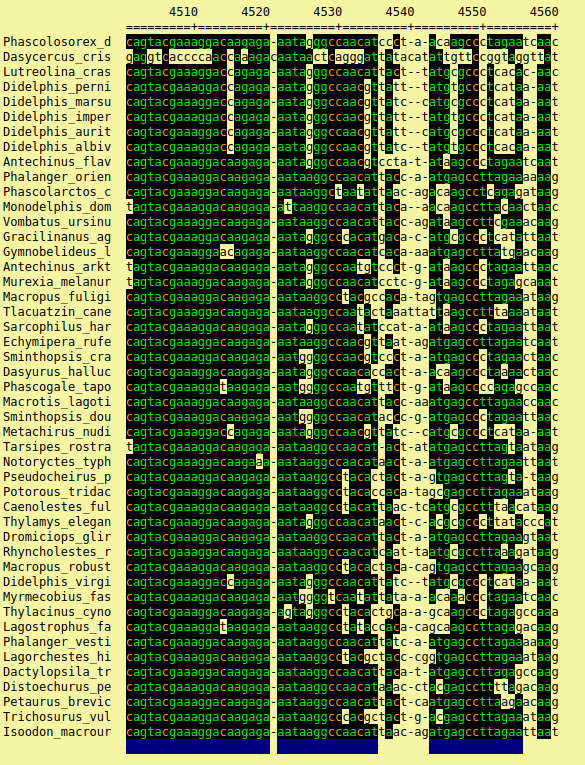

Gblocks HTML output

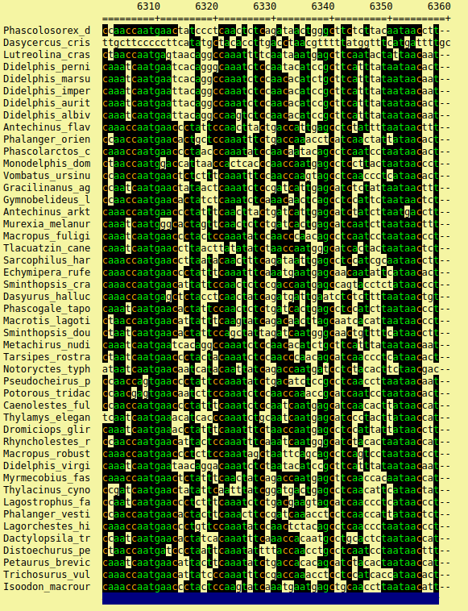

Gblocks HTML output

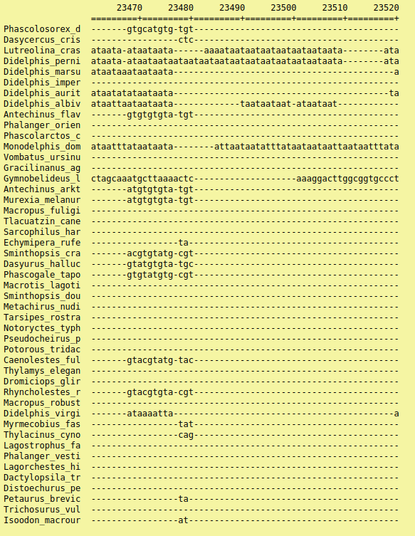

Gblocks HTML output

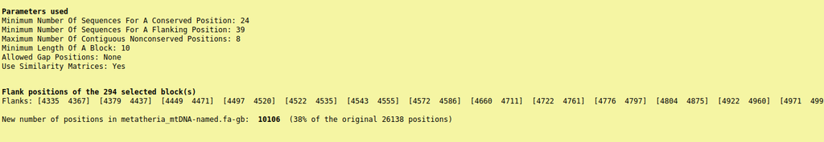

Gblocks HTML output

**Q2. What is the reason for the large gaps in the beginning and end of the alignment?**

- One of the features of mitochondrial genomes is the so-called control region, an extremely variable area (especially in the aptly named hypervariable regions) responsible for mitochondrial replication
- Since it is not conserved over long timescales, it is useless for our phylogeny (however, it is extremely useful for studies of human populations over tens of ky)
- Since the circular mtDNA has to be cut somewhere to be stored in databases as a linear sequence, the cut is made in the control region, resulting in the beginning and end of an alignment containing large gaps - the control region length and cut placement varies across species

**Q3. Why does Gblocks need to be used?**

```bash
cp metatheria_mtDNA-named.nex ~/Assignments/Assignment_3/mb_outputs/metatheria_mtDNA-named.nex
cd ~/Assignments/Assignment_3/mb_outputs
```

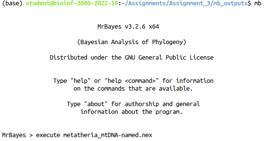

Mr Bayes

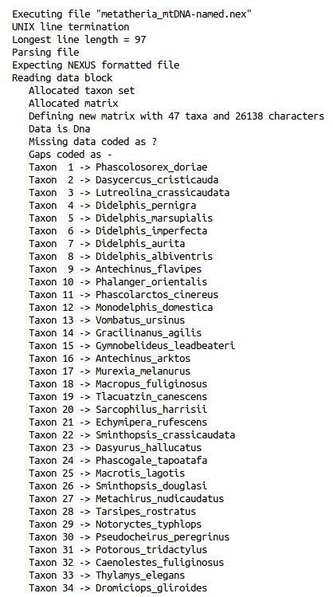

Mr Bayes

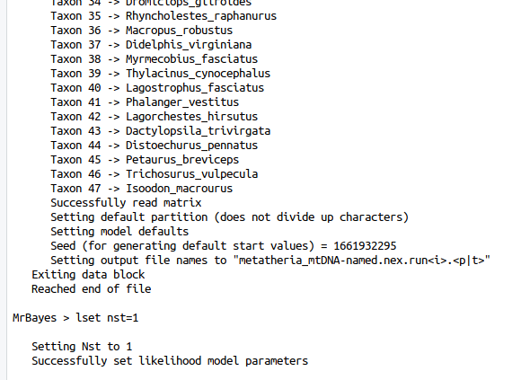

Mr Bayes

**Q4. How many taxa were read into memory?**

- 47 taxa

**Q5. How many characters are being used?**

**Q6. What substitution models do the Nst options correspond to?**

- 1 sets all substitution rates to be equal (Jukes-Canter model)
- 2 allows difference in rates of transitions (purine-purine or pyrimidine-pyrimidine) and transversions (purine-pyrimidine) (Kimura or HKY model)
- 6 allows individual letter pair substitution rates to be different (General Time Reversible model)
- In the practical, two bovine trees were constructed using `Nst` set to 1 and 6, and will be compared below
- For the single marsupial tree, model 1 was used ***
- The actual analysis is run with `mcmc` and some parameters

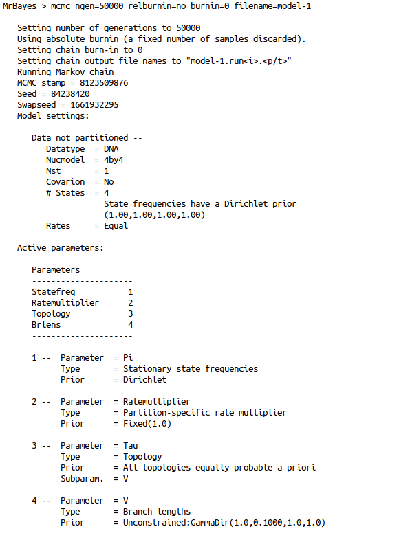

Mr Bayes

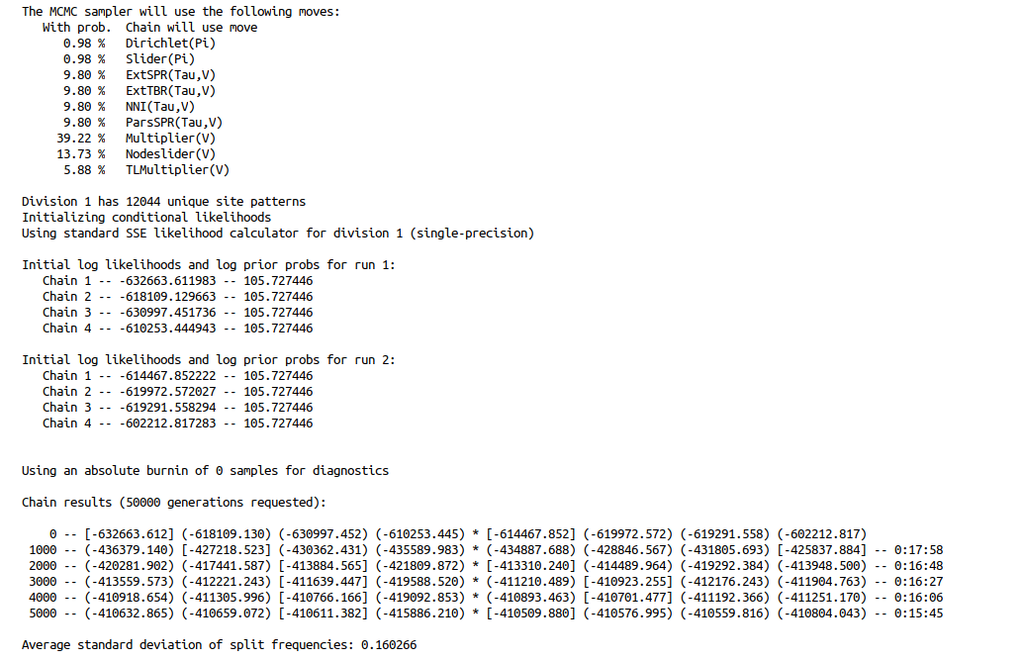

Mr Bayes

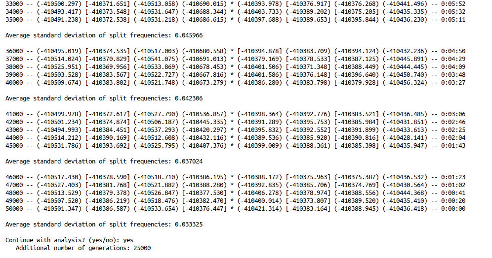

Mr Bayes

- Note that the analysis is continued at this stage: the “Average standard deviation of split frequencies” was judged to still be steeply decreasing, and the decision to continue was made in accordance with the Mr Bayes [Tutorial](http://mrbayes.sourceforge.net/wiki/index.php/Tutorial_3.2#When_to_Stop_the_Analysis)

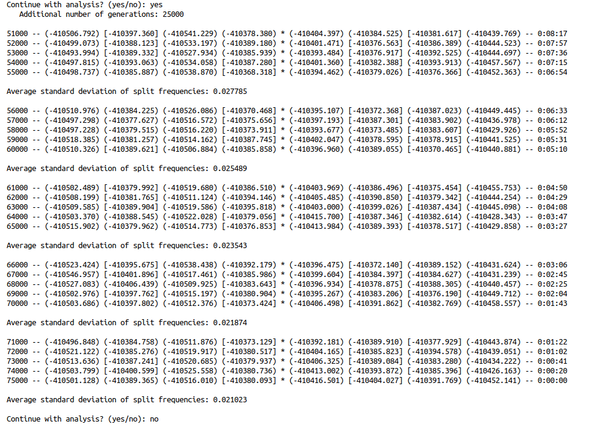

Mr Bayes

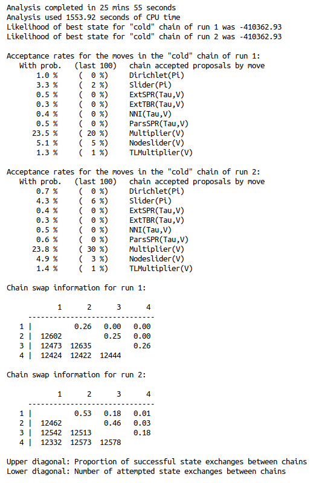

Mr Bayes

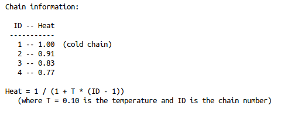

Mr Bayes

- `sump` outputs a variety of parameter summaries for the analysis just completed

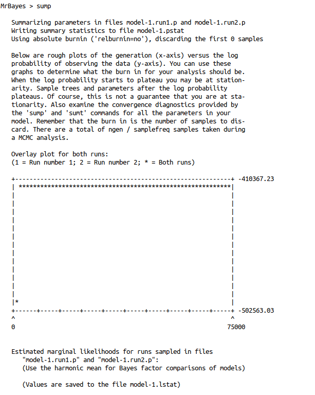

Mr Bayes

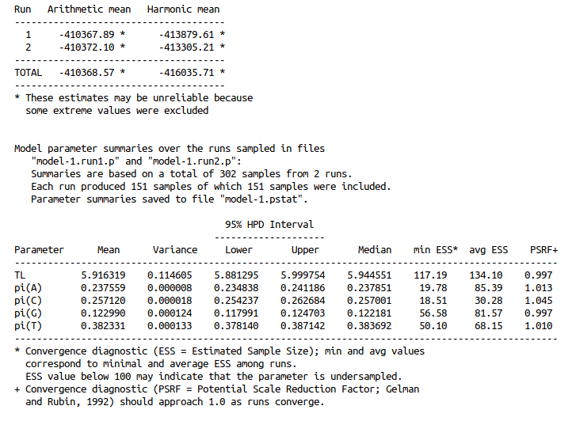

Mr Bayes

**Q7, Q8. Describe what the output graph shows. Approximately when does the plateau start in terms of number of samples?**

```bash
head -n10 ~/Assignments/Assignment_3/mb_outputs/model-1.con.tre
```

```
## #NEXUS
## [ID: 8123509876]
## begin taxa;
##  dimensions ntax=47;
##  taxlabels
##      Phascolosorex_doriae
##      Dasycercus_cristicauda
##      Lutreolina_crassicaudata
##      Didelphis_pernigra
##      Didelphis_marsupialis
```

7. The consensus tree is visualised using FigTree

Bovine tree, model 1, mitochondrial

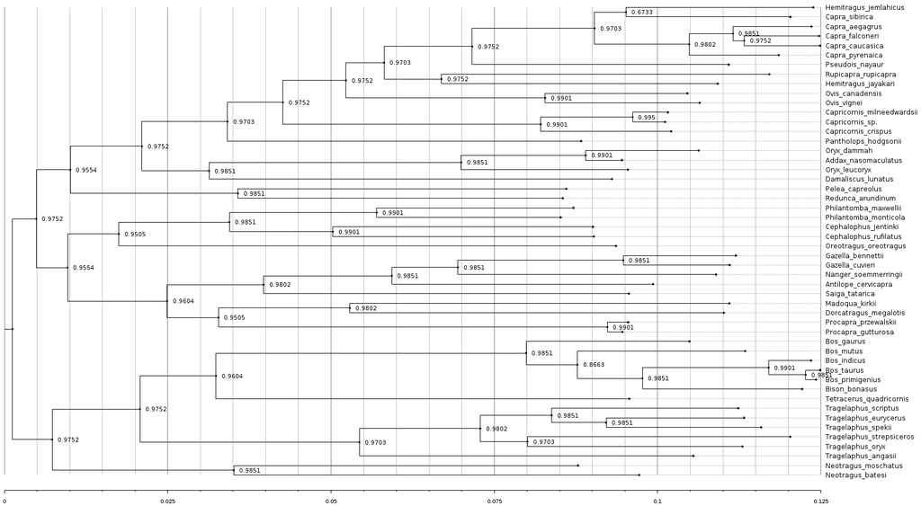

Bovine tree, model 6, mitochondrial

[figure not shown]

Bovine tree, nuclear

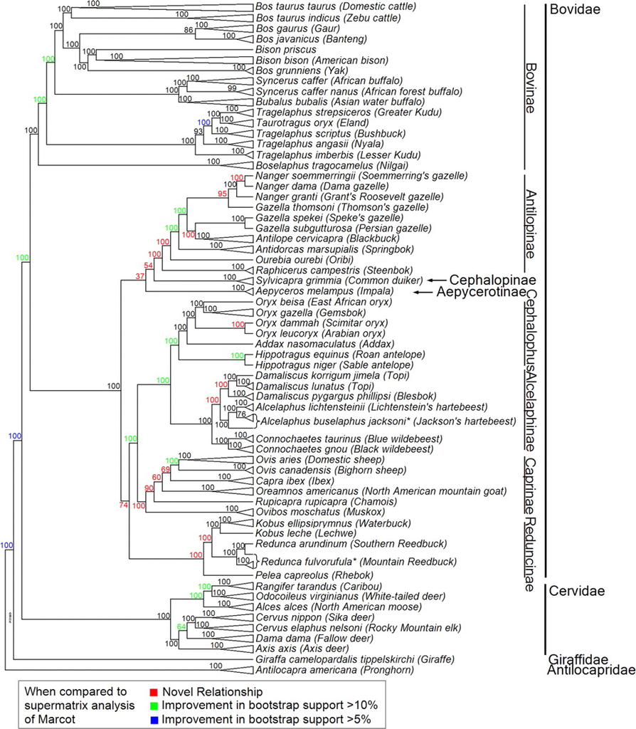

Marsupial tree, model 1, mitochondrial

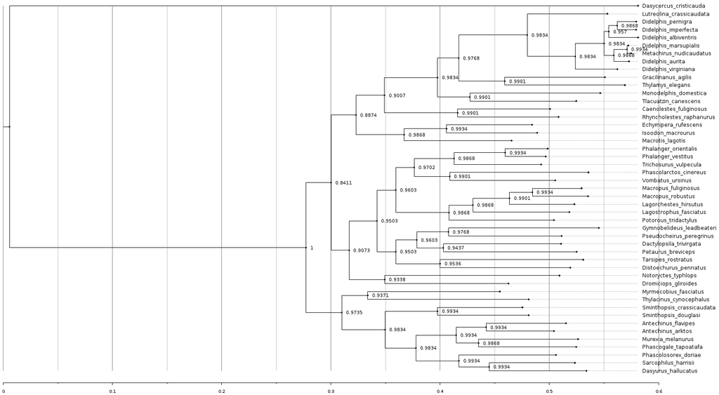

**Q9. Do the bovine trees from the two models differ?**

[figure not shown]

Bovine tree comparison

**Q10. How does the branch support differ between the two bovine trees?**

**Q11. Do the bovine trees agree with the known taxonomic groupings?**

**Q12. What two species are the best to use as an outgroup in the marsupial tree?**

- *Dasycercus cristicauda* stands out as being extremely distantly related to the rest of the species in the tree, and is an obvious choice for an outgroup to compare relationships between other marsupials
- However, it is so distantly related that one might want a closer outgroup for finer analysis
- The first bifurcation after *D. cristicauda* produces one clade much smaller than the other (species *Mymecobius fasciatus* to *Dasyurus hallucatus* in the figure), and one of these species can be chosen as an outgroup (barring any other biological considerations)

**Q13. Which two leaves are the closest related/have the shortest branch in the marsupial tree?**

- Two species with the shortest distance between them are *Didelphis marsupialis* and *Metachirus nudicaudatus*

**Q14. What is the evolutionary distance between these two leaves?**

- In this phylogram, branch length represents evolutionary distance in units related to sequence divergence, themselves able to be converted to evolutionary time using molecular clock methods
- By comparing to the scale axis, the distance between these species is 0.0079 (sum of branch lengths to the node immediately before them)

**Q15. Which two of the following species in the marsupial tree are most closely related?** 1. **silky-shrew oppossum** 2. **Tasmanian wolf** 3. **koala** 4. **platypus**

- The koala and the silky-shrew oppossum belong to the one half of the second bifurcation, while the Tasmanian wolf belongs to the other, making the first two more closely related (the platypus is not present in this tree) ***